# Assignment_1

Cornelia Sindermann

15 10 2019

# Preparing Data

Downloading data from Internet and reading it into R:

```r
#download
url <- "https://d396qusza40orc.cloudfront.net/repdata%2Fdata%2Factivity.zip"
tempFile <- tempfile()
download.file(url, tempFile, method = "curl")
#read into R
Data_Assignment <- read.csv(unz(tempFile, "activity.csv"), header = TRUE)
unlink(tempFile)
```

Columns of the file are not in the appropriate format; this needs to be changed

```r
Data_Assignment$steps <- as.numeric(Data_Assignment$steps)
Data_Assignment$date <- as.Date(Data_Assignment$date)
Data_Assignment$interval <- as.numeric(Data_Assignment$interval)
```

What to see from the data:

1. There are 61 different days
2. Each interval occurs 61 times (hence, for each day)

# Questions / Assignments:

## What is mean total number of steps taken per day?

1. Calculate the total number of steps taken per day

```r
Total_Steps_Day <- aggregate(Data_Assignment[,1], by=list(Data_Assignment$date), FUN=sum, na.rm=TRUE)
```

2. Make a histogram of the total number of steps taken each day

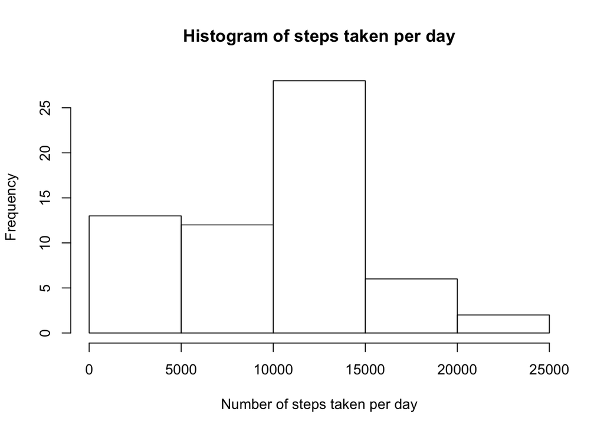

```r
hist(Total_Steps_Day[,2],
     main = "Histogram of steps taken per day",
     xlab="Number of steps taken per day")
```

3. Calculate and report the mean and median of the total number of steps taken per day

```r
#mean
mean(Total_Steps_Day[,2])
```

```
## [1] 9354.23
```

```r
#median
median(Total_Steps_Day[,2])
```

```
## [1] 10395
```

## What is the average daily activity pattern?

1. Make a time series plot (i.e. type = “l”) of the 5-minute interval (x-axis) and the average number of steps taken, averaged across all days (y-axis)

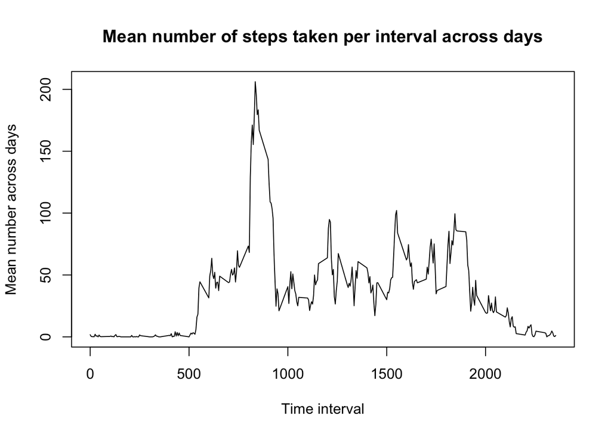

```r
#Calculate steps per intervall across all days
Mean_Steps_Interv <- aggregate(Data_Assignment[,1], by=list(Data_Assignment$interval), FUN=mean, na.rm=TRUE)

#design time series plot
plot(Mean_Steps_Interv[,1], Mean_Steps_Interv[,2], type="l",
     main="Mean number of steps taken per interval across days",
     xlab ="Time interval",
     ylab="Mean number across days")
```

2. Which 5-minute interval, on average across all the days in the dataset, contains the maximum number of steps?

```r
#search interval with highest value in "Mean_Steps_Interv"
max_MeanStep <- max(Mean_Steps_Interv[,2], na.rm=TRUE)
#Highest value is above 206 --> Therefore, select case were x is greater than 206
max_interval <- subset(Mean_Steps_Interv, x > 206)
```

Time interval 835 has highest mean steps taken across days.

## Imputing missing values

1. Calculate and report the total number of missing values in the dataset (i.e. the total number of rows with NAs)

```r
#Count NAs across all rows and columns
sum(is.na(Data_Assignment))
```

```
## [1] 2304
```

```r
#Count NAs within each column
sum(is.na(Data_Assignment[,1]))
```

```
## [1] 2304
```

```r
sum(is.na(Data_Assignment[,2])) # 0 NAs
```

```
## [1] 0
```

```r
sum(is.na(Data_Assignment[,3])) # 0 NAs
```

```
## [1] 0
```

The total number of NAs and also the total number of rows with NAs is 2304 (all NAs are in first column)

2. Devise a strategy for filling in all of the missing values in the dataset. The strategy does not need to be sophisticated. For example, you could use the mean/median for that day, or the mean for that 5-minute interval, etc.

```r
#I use the mean steps per interval to be imputed for the NAs
Mean_Steps_Interv_2 <- aggregate(steps ~ interval, data=Data_Assignment, FUN=mean)
Impute_NA <- numeric()
for (i in 1:nrow(Data_Assignment)) {
    obs <- Data_Assignment[i, ]
    if (is.na(obs$steps)) {
        steps <- subset(Mean_Steps_Interv_2, interval == obs$interval)$steps
    } else {
        steps <- obs$steps
    }
    Impute_NA <- c(Impute_NA, steps)
}
```

3. Create a new dataset that is equal to the original dataset but with the missing data filled in.

```r
Imputed_Data_Assignment <- Data_Assignment
Imputed_Data_Assignment$steps <- Impute_NA
```

4. Make a histogram of the total number of steps taken each day and Calculate and report the mean and median total number of steps taken per day. Do these values differ from the estimates from the first part of the assignment? What is the impact of imputing missing data on the estimates of the total daily number of steps?

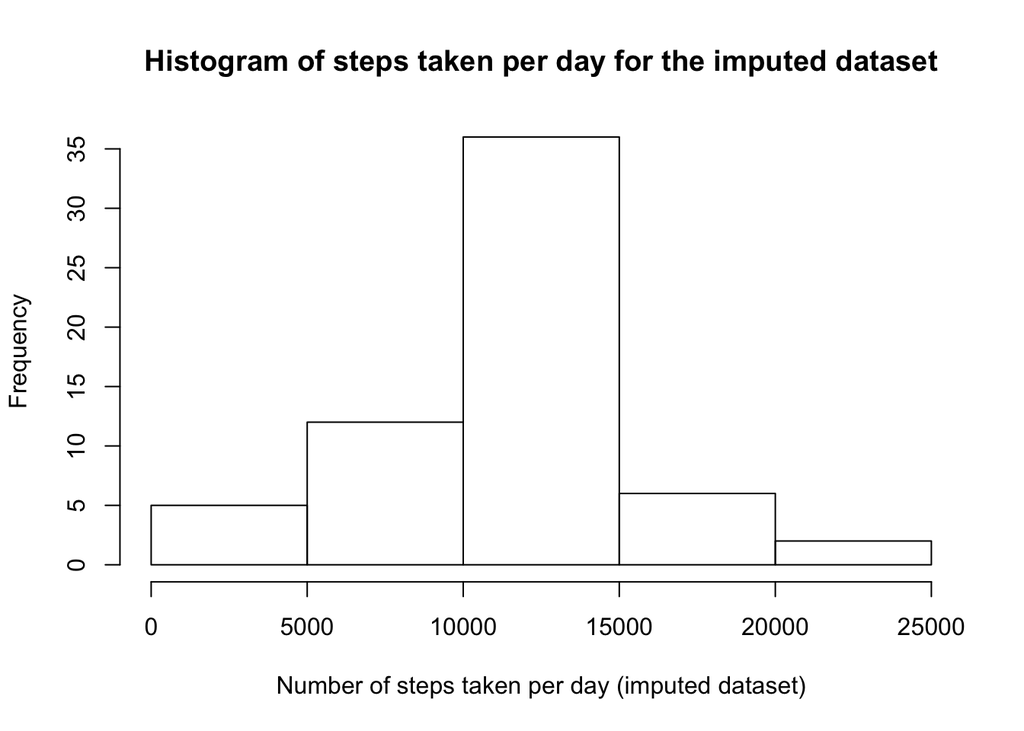

```r
#1. Calculate total number of steps taken each day (for the imputed dataset)
Total_Steps_Day_2 <- aggregate(Imputed_Data_Assignment[,1],
                               by=list(Imputed_Data_Assignment$date), FUN=sum, na.rm=TRUE)

#2. Build histogram
hist(Total_Steps_Day_2[,2],
     main="Histogram of steps taken per day for the imputed dataset",
     xlab="Number of steps taken per day (imputed dataset)")
```

```r
#3. Calculate mean
mean(Total_Steps_Day_2[,2]) #10766.19
```

```
## [1] 10766.19
```

```r
#4. Calculate median
median(Total_Steps_Day_2[,2]) #10766.19
```

```
## [1] 10766.19
```

```r
# Do mean and median differ (without vs. with imputed data)?
# New mean and median (imputed data): 10766.19; old mean and median (no imputed data): 9354.23, 10395
```

New mean and median are the same AND both are higher than previous mean and median

## Are there differences in activity patterns between weekdays and weekends?

1. Create a new factor variable in the dataset with two levels – “weekday” and “weekend” indicating whether a given date is a weekday or weekend day.

```r
#Built days (7 days)
Days <- weekdays(Data_Assignment$date)

#Built Weekdays vs. Weekend
Daylevel <- vector()
for (i in 1:nrow(Data_Assignment)) {
    if (Days[i] == "Saturday") {
        Daylevel[i] <- "Weekend"
    } else if (Days[i] == "Sunday") {
        Daylevel[i] <- "Weekend"
    } else {
        Daylevel[i] <- "Weekday"
    }
}

Data_Assignment$Daylevel <- Daylevel
Data_Assignment$Daylevel <- as.factor(Data_Assignment$Daylevel)
```

2. Make a panel plot containing a time series plot (i.e. type = “l”) of the 5-minute interval (x-axis) and the average number of steps taken, averaged across all weekday days or weekend days (y-axis). See the README file in the GitHub repository to see an example of what this plot should look like using simulated data.

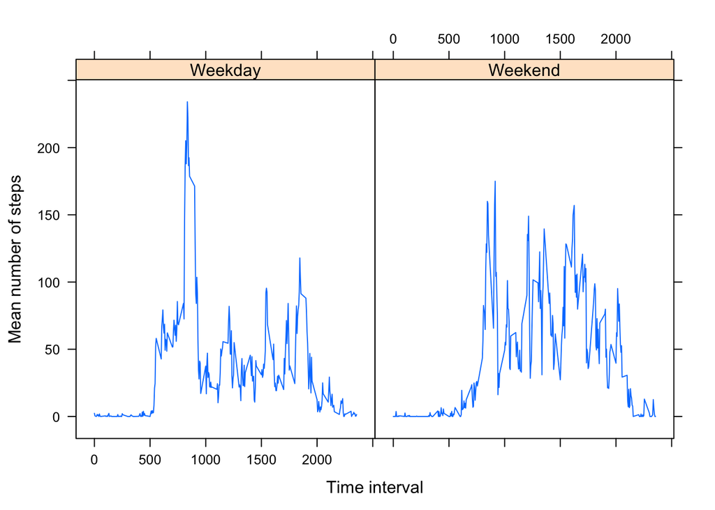

```r
StepsWeekEnd <- aggregate(steps ~ interval + Daylevel, data = Data_Assignment, FUN=mean)

library(lattice)
xyplot(steps ~ interval | Daylevel, StepsWeekEnd, type = "l", layout = c(2, 1),
    xlab = "Time interval", ylab = "Mean number of steps")
```